# Autism Doesn’t Hold People Back at Work. Discrimination Does.

[Neurodiversity](https://hbr.org/topic/subject/neurodiversity)

# Autism Doesn’t Hold People Back at Work. Discrimination Does.

Neurodiversity discrimination is systemic, but there are ways to defy it.

by

- [Ludmila N. Praslova](https://hbr.org/search?term=ludmila%20n.%20praslova)

December 13, 2021 · Long read

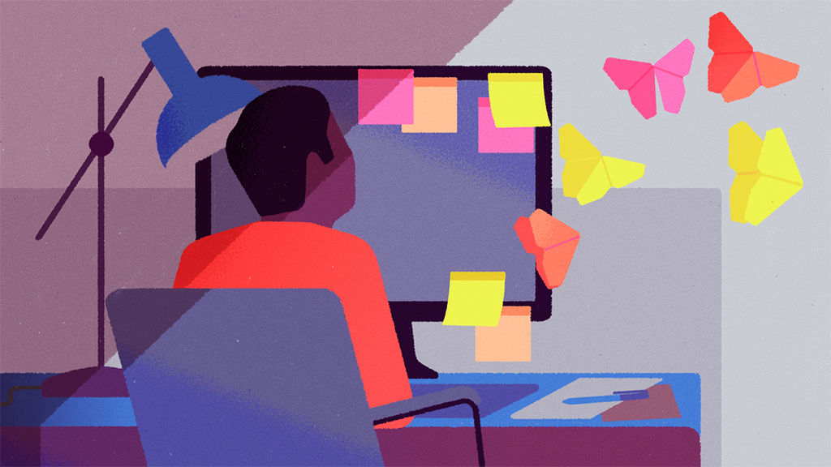

Illustration by María Hergueta

Summary.

Did you know that an autistic professional is up to 140% more productive than an average employee when properly matched to a job that fits their skills? Yet, discrimination against neurodivergent people continues. That’s because most of the “common” workplace practices at the workplace are established for neurotypicality. While the onus to change this really lies with the organizations, the author offers a few strategies to help neurodivergent employees take control of their own success at work.

- First, know that your disclosure is your decision. When you own who you are, you may end up finding some allies or even inspire others to disclose their disability or identity. That said, don’t pressure yourself. If you’re not comfortable talking about your identity or the environment doesn’t feel conducive, take your time.
- Define what career success looks like for you. Your career path depends on your goals and priorities. Take the time to understand what you value, why you value it, and how you see those impacting your long-term growth.
- For undiagnosed or undisclosed autistics, job crafting may be an effective strategy for a sustainable work-life. Job crafting refers to changing some aspects of your tasks, mindset, and relationships to align with your strengths.
- Explore your purpose at work. For instance, joining Employee Resource Groups (ERGs) and committees focused on bringing people of specific identities or life circumstances together (e.g., culture, disability, caregiving) can help you share your ideas with like-minded and supportive colleagues.
- Finally, know that not all office politics are bad. While there may be toxic colleagues or situations pulling you down, you can learn to be your own ally.
- Post
- Post
- Share
- Save
- Print

Where your work meets your life. See more from Ascend [here](https://hbr.org/insight-center/ascend).

Every time I write about autism and neurodiversity, my inbox fills with notes from talented young professionals. I’ve heard from people who mask their autism to avoid stereotyping or discrimination at work. I’ve read painful recollections from employees who are shunned, bullied, exploited, or [underpaid](https://www.bloomberg.com/opinion/articles/2021-06-05/post-covid-workplace-changes-should-include-closing-the-autism-gap) as a result of being [neurodivergent](https://neurodiversity2.blogspot.com/p/what.html). Then, there are those who were rejected or fired after disclosing autism, ADHD, or another neuro-difference. Some of them want my advice. Others want to be heard. Their stories vary, but each resonates, in some way, with my own.

[figure not shown]